# Practicle machine learining - Assignment project 1

sravan k

Sunday 27 July 2014

Loading required libraries (Results Hidden, Warnings OFF, Messages OFF), and setting seed for reproducibility.

```r
library(randomForest)
set.seed(1234)
```

Clearing existing objects, Reading (& caching) Files, and making training and validation data sets.

```r
rm(list=ls())
trainingCSV = read.csv("pml-training.csv")
inTrain = sample(1:nrow(trainingCSV), size=0.2*nrow(trainingCSV))
training <- trainingCSV[inTrain, ]
validation <- trainingCSV[-inTrain, ]
```

Creating summary and viewing the top few records, and seeing paired scatter plots in the training file (Results Hidden, Output Cached).

```r
summary(training)
head(training)
```

Trying to explore the data, esp the relations between variables.

There we may try to see multiple subsetted plot (as some examples given), or better still, see the tabular correlation matrix of the ones which are highly correlated.

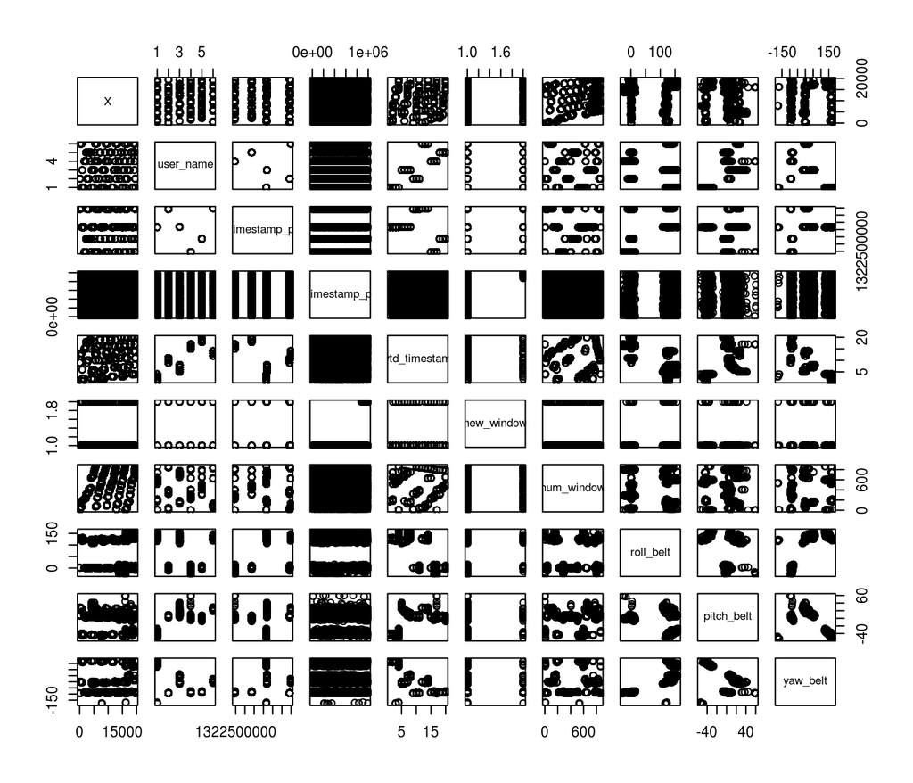

```r
pairs(training[1:10000,1:10])
```

```r
goodVar<-c((colSums(is.na(training[,-160])) >= 0.4*nrow(training)),160)
training<-training[,goodVar]
dim(training)
```

```
## [1] 3924   68
```

```r
validation<-validation[,goodVar]
dim(validation)
```

```
## [1] 15698    68
```

```r
training<-training[complete.cases(training),]
dim(training)
```

```
## [1] 3924   68
```

Training the model (RandomForest) on the training data set.

```r
model <- randomForest(classe~.,data=training)
print(model)
```

```
##
## Call:
##  randomForest(formula = classe ~ ., data = training)
##                Type of random forest: classification
##                      Number of trees: 500
## No. of variables tried at each split: 8
##
##         OOB estimate of  error rate: 0.05%
## Confusion matrix:
##      A   B   C   D   E class.error
## A 1112   0   0   0   0    0.000000
## B    0 769   0   0   0    0.000000
## C    0   0 696   0   0    0.000000
## D    0   0   0 624   1    0.001600
## E    0   0   0   1 721    0.001385
```

```r
head(importance(model))
```

```
##     MeanDecreaseGini
## X              28.87
## X.1            48.41
## X.2            37.41
## X.3            33.23
## X.4            54.15
## X.5            53.38
```

Evaluating the model on the evaluation dataset.

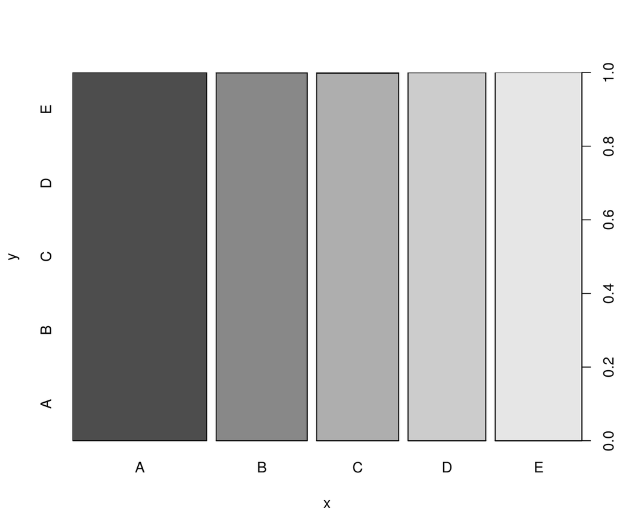

```r
plot(predict(model,newdata=validation[,-ncol(validation)]),validation$classe)
```

```r
accurate<-c(as.numeric(predict(model,newdata=validation[,-ncol(validation)])==validation$classe))
accuracy<-sum(accurate)*100/nrow(validation)
message("Expected out of sample error using cross-validation is = " , format(round(100-accuracy, 2), nsmall = 2), "%")
```

```
## Expected out of sample error using cross-validation is = 0.05%
```

Predicting the new values in the testing csv provided.

```r
testing =  read.csv("pml-testing.csv")
dim(testing)
```

```
## [1]  20 160
```

```r
testing<-testing[,goodVar]
dim(testing)
```

```
## [1] 20 68
```

```r
predictions<-predict(model,newdata=testing)
predictions
```

```
##  1  2  3  4  5  6  7  8  9 10 11 12 13 14 15 16 17 18 19 20
##  A  A  A  A  A  A  A  A  A  A  A  A  A  A  A  A  A  A  A  A
## Levels: A B C D E
```

I faced some issues with Caret package in Ubuntu 12.04. so i didnot used confusion matrix functionality.

thanks

sravan k.